# Exploration initiale des corrélations

Ce notebook a pour but l'exploration des corrélations entre l'indice de bonheur et les autres indicateurs retenus.  
Les combinaisons d'années/pays sont considérer comme des observations distinctes pour l'évaluation des corrélations.  
Le notebook utilise les données du fichier "data/merged/global2.csv".

```python
import numpy as np
import pandas as pd
import matplotlib.pyplot as plt
import scipy.stats as stats
from math import log, sqrt
```

### Lectures des données

```python
df_global = pd.read_csv("data/merged/global2.csv", sep=";")
```

```python
df_global
```

|  | annee | Country | Happiness Score | nativity | migration | health_expend | educ_expend | gdp | taxes | budget | milit |
| --- | --- | --- | --- | --- | --- | --- | --- | --- | --- | --- | --- |
| 0 | 2015 | Switzerland | 7.587 | 10.50 | 4.74 | 11.5 | 5.3 | 58100.0 | 33.60 | 0.3 | 0.64 |
| 1 | 2015 | Iceland | 7.561 | 13.91 | 4.43 | 9.1 | 7.4 | 43600.0 | 45.30 | 0.1 | 0.13 |
| 2 | 2015 | Denmark | 7.527 | 10.27 | 2.20 | 10.6 | 8.7 | 44300.0 | 55.50 | -1.4 | 1.37 |
| 3 | 2015 | Norway | 7.522 | 12.14 | 7.25 | 9.6 | 6.6 | 66900.0 | 57.50 | 12.5 | 1.40 |
| 4 | 2015 | Canada | 7.427 | 10.28 | 5.66 | 10.9 | 5.3 | 44800.0 | 37.60 | -2.3 | 1.00 |
| ... | ... | ... | ... | ... | ... | ... | ... | ... | ... | ... | ... |
| 1333 | 2023 | Congo (Kinshasa) | 3.207 | 39.64 | -0.63 | 4.1 | 2.7 | 1100.0 | 11.20 | -0.9 | 1.30 |
| 1334 | 2023 | Zimbabwe | 3.204 | 32.77 | -4.74 | 3.4 | 3.9 | 2100.0 | 7.21 | -9.6 | 1.80 |
| 1335 | 2023 | Sierra Leone | 3.138 | 31.49 | 1.72 | 8.8 | 9.1 | 1600.0 | 15.60 | -7.9 | 0.40 |
| 1336 | 2023 | Lebanon | 2.392 | 12.86 | -0.94 | 8.0 | 1.7 | 13000.0 | 8.90 | -6.9 | 4.60 |
| 1337 | 2023 | Afghanistan | 1.859 | 34.79 | -0.10 | 15.5 | 2.9 | 1500.0 | 9.90 | -15.1 | 3.10 |

1338 rows × 11 columns

```python
import statsmodels.api as sm
```

## Évaluations des corrélations des variables avec l'indice de bonheur

### Natalité

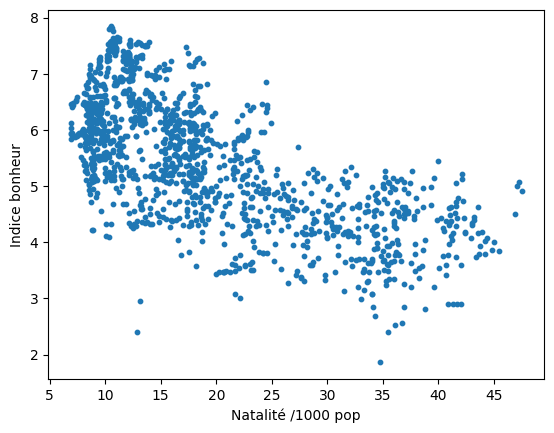

```python
plt.scatter(df_global.nativity, df_global["Happiness Score"], s=10)
plt.ylabel('Indice bonheur')
plt.xlabel('Natalité /1000 pop')
plt.show()
```

```python
df_temp = df_global[df_global.nativity.notnull()]
c_nat = stats.pearsonr(df_temp.nativity, df_temp["Happiness Score"])
c_nat
```

```
PearsonRResult(statistic=-0.6776976169501687, pvalue=1.3687078099948147e-180)
```

```python
c_nat.statistic**2
```

```
0.4592740600199376
```

Le R<sup>2</sup> de 0.4593 nous indique qu'il y a corrélation assez élevée avec la natalité.  
On peut aussi l'observer visuellement dans le graphique.

### Migration

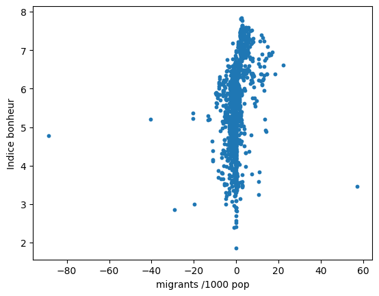

```python
plt.scatter(df_global.migration, df_global["Happiness Score"], s=10)
plt.ylabel('Indice bonheur')
plt.xlabel('migrants /1000 pop')
plt.show()
```

```python
df_temp = df_global[df_global.migration.notnull()]
c_mig = stats.pearsonr(df_temp.migration, df_temp["Happiness Score"])
c_mig
```

```
PearsonRResult(statistic=0.28959067841345265, pvalue=2.9062509284778466e-27)
```

```python
c_mig.statistic**2
```

```
0.08386276102396376
```

Le R<sup>2</sup> de 0.0839 nous indique qu'il n'y a pas de corrélation notable avec la migration.

### Dépenses en santé

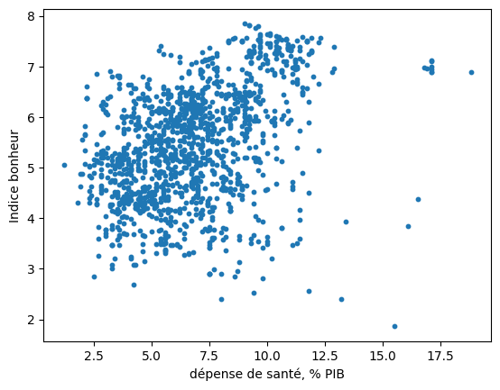

```python
plt.scatter(df_global.health_expend, df_global["Happiness Score"], s=10)
plt.ylabel('Indice bonheur')
plt.xlabel('dépense de santé, % PIB')
plt.show()
```

```python
df_temp = df_global[df_global.health_expend.notnull()]
c_he = stats.pearsonr(df_temp.health_expend, df_temp["Happiness Score"])
c_he
```

```
PearsonRResult(statistic=0.39496947823807427, pvalue=3.444309657426343e-51)
```

```python
c_he.statistic**2
```

```
0.15600088873965662
```

Le R<sup>2</sup> de 0.1560 nous indique qu'il y a une certaine corrélation (mais plutôt faible) avec les dépenses en santé.  
On peut aussi l'observer visuellement dans le graphique.

### Dépenses en éducation

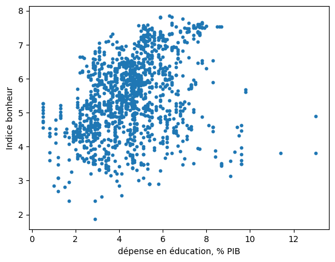

```python
plt.scatter(df_global.educ_expend, df_global["Happiness Score"], s=10)
plt.ylabel('Indice bonheur')
plt.xlabel('dépense en éducation, % PIB')
plt.show()
```

```python
df_temp = df_global[df_global.educ_expend.notnull()]
c_ee = stats.pearsonr(df_temp.educ_expend, df_temp["Happiness Score"])
c_ee
```

```
PearsonRResult(statistic=0.3061623774218314, pvalue=1.9782017765502016e-30)
```

```python
c_ee.statistic**2
```

```
0.09373540134858793
```

Le R<sup>2</sup> de 0.0937 nous indique que la corrélation est très faible avec les dépenses en éducation.

### PIB per capitat

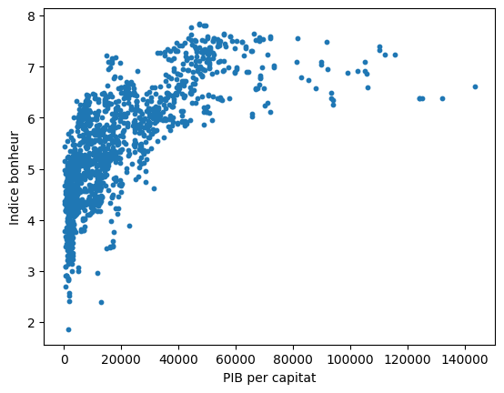

```python
plt.scatter(df_global.gdp, df_global["Happiness Score"], s=10)
plt.ylabel('Indice bonheur')
plt.xlabel('PIB per capitat')
plt.show()
```

```python
df_temp = df_global[df_global.gdp.notnull()]
c_gdp = stats.pearsonr(df_temp.gdp, df_temp["Happiness Score"])
c_gdp
```

```
PearsonRResult(statistic=0.7192895342388678, pvalue=1.354074648418761e-213)
```

```python
c_gdp.statistic**2
```

```
0.5173774340655674
```

Le R<sup>2</sup> de 0.5174 nous indique qu'il y a corrélation élevée avec le PIB.  
On peut aussi l'observer visuellement dans le graphique.

### Taxes et autres revenus

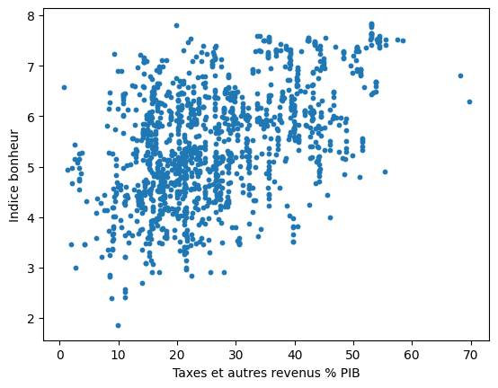

```python
plt.scatter(df_global.taxes, df_global["Happiness Score"], s=10)
plt.ylabel('Indice bonheur')
plt.xlabel('Taxes et autres revenus % PIB')
plt.show()
```

```python
df_temp = df_global[df_global.taxes.notnull()]
c_taxes = stats.pearsonr(df_temp.taxes, df_temp["Happiness Score"])
c_taxes
```

```
PearsonRResult(statistic=0.4766211164885423, pvalue=7.955108567405368e-77)
```

```python
c_taxes.statistic**2
```

```
0.22716768868278459
```

### Surplus ou déficit budgétaire

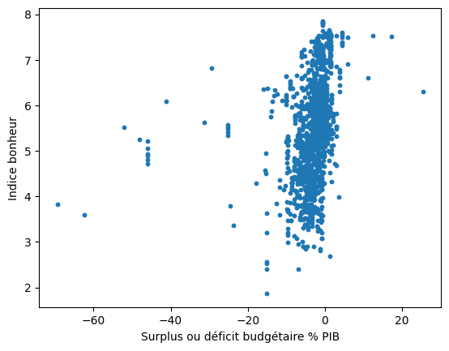

```python
plt.scatter(df_global.budget , df_global["Happiness Score"], s=10)
plt.ylabel('Indice bonheur')
plt.xlabel('Surplus ou déficit budgétaire % PIB')
plt.show()
```

```python
df_temp = df_global[df_global.budget.notnull()]
c_budget = stats.pearsonr(df_temp.budget, df_temp["Happiness Score"])
c_budget
```

```
PearsonRResult(statistic=0.2878165363574443, pvalue=6.168324719764151e-27)
```

```python
c_budget.statistic**2
```

```
0.08283835860079607
```

Le R<sup>2</sup> de 0.0828 nous indique qu'il n'y a pas de corrélation notable avec le surplus ou déficit budgétaire.

### Dépenses militaires

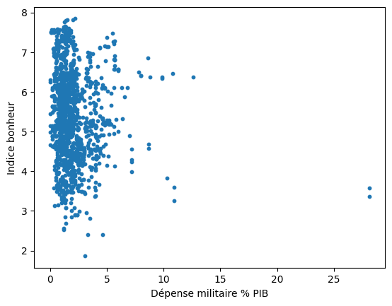

```python
plt.scatter(df_global.milit, df_global["Happiness Score"], s=10)
plt.ylabel('Indice bonheur')
plt.xlabel('Dépense militaire % PIB')
plt.show()
```

```python
df_temp = df_global[df_global.milit.notnull()]
c_milit = stats.pearsonr(df_temp.milit, df_temp["Happiness Score"])
c_milit
```

```
PearsonRResult(statistic=-0.11928174040745117, pvalue=1.2158956079478953e-05)
```

```python
c_milit.statistic**2
```

```
0.01422813359463057
```

Le R<sup>2</sup> de 0.0142 nous indique qu'il n'y a pas de corrélation notable avec les dépenses militaires.

## Évaluation des variables monétaire per capita

Pour les variables monétaires exprimées en pourcentage du PIB, nous allons faire les mêmes évaluations per capita.

### Dépenses en santé (absolut per capita)

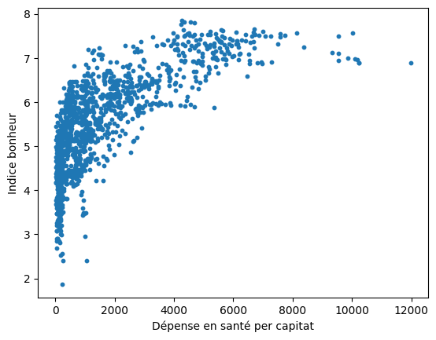

```python
plt.scatter((df_global.health_expend/100) * df_global.gdp, df_global["Happiness Score"], s=10)
plt.ylabel('Indice bonheur')
plt.xlabel('Dépense en santé per capitat')
plt.show()
```

Mais quelle est cette combinaison pays/année qui sort du lot autant du lot ?

```python
df_global.loc[(df_global.health_expend/100) * df_global.gdp == max((df_global.health_expend/100) * df_global.gdp)]
```

|  | annee | Country | Happiness Score | nativity | migration | health_expend | educ_expend | gdp | taxes | budget | milit |
| --- | --- | --- | --- | --- | --- | --- | --- | --- | --- | --- | --- |
| 1244 | 2023 | United States | 6.894 | 12.21 | 3.01 | 18.8 | 6.1 | 63700.0 | 9.86 | -3.4 | 3.5 |

```python
df_temp = df_global[df_global.gdp.notnull() & df_global.health_expend.notnull()]
c_he_gdp = stats.pearsonr((df_temp.health_expend/100) * df_temp.gdp, df_temp["Happiness Score"])
c_he_gdp
```

```
PearsonRResult(statistic=0.7351526682006329, pvalue=8.145976045175225e-228)
```

```python
c_he_gdp.statistic**2
```

```
0.5404494455625097
```

Le R<sup>2</sup> de 0.5404 nous indique une corrélation bien plus grande lorsque calculé ainsi.

### Dépenses en éducation (absolut per capita)

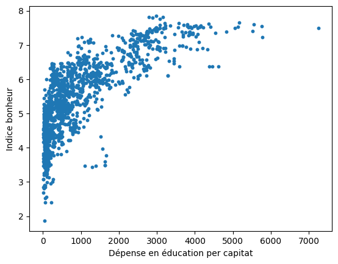

```python
plt.scatter((df_global.educ_expend/100) * df_global.gdp, df_global["Happiness Score"], s=10)
plt.ylabel('Indice bonheur')
plt.xlabel('Dépense en éducation per capitat')
plt.show()
```

Mais quelle est cette combinaison pays/année qui sort du lot autant du lot ?

```python
df_global.loc[(df_global.educ_expend/100) * df_global.gdp == max((df_global.educ_expend/100) * df_global.gdp)]
```

|  | annee | Country | Happiness Score | nativity | migration | health_expend | educ_expend | gdp | taxes | budget | milit |
| --- | --- | --- | --- | --- | --- | --- | --- | --- | --- | --- | --- |
| 786 | 2020 | Norway | 7.488 | 12.2 | 4.0 | 10.4 | 7.9 | 91781.0 | 54.4 | 4.4 | 1.8 |

```python
df_temp = df_global[df_global.gdp.notnull() & df_global.educ_expend.notnull()]
c_ee_gdp = stats.pearsonr((df_temp.educ_expend/100) * df_temp.gdp, df_temp["Happiness Score"])
c_ee_gdp
```

```
PearsonRResult(statistic=0.7575741614740986, pvalue=9.12690844134064e-250)
```

```python
c_ee_gdp.statistic**2
```

```
0.5739186101331837
```

Le R<sup>2</sup> de 0.5739 nous indique une corrélation bien plus grande lorsque calculé ainsi.

### Taxes et autres revenus per capita

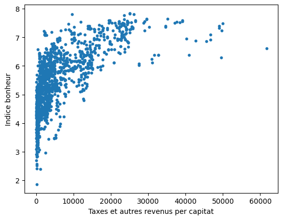

```python
plt.scatter((df_global.taxes/100) * df_global.gdp, df_global["Happiness Score"], s=10)
plt.ylabel('Indice bonheur')
plt.xlabel('Taxes et autres revenus per capitat')
plt.show()
```

Mais quelle est cette combinaison pays/année qui sort du lot autant du lot ?

```python
df_global.loc[(df_global.taxes/100) * df_global.gdp == max((df_global.taxes/100) * df_global.gdp)]
```

|  | annee | Country | Happiness Score | nativity | migration | health_expend | educ_expend | gdp | taxes | budget | milit |
| --- | --- | --- | --- | --- | --- | --- | --- | --- | --- | --- | --- |
| 27 | 2015 | Qatar | 6.611 | 9.84 | 22.39 | 2.2 | 2.4 | 143400.0 | 43.0 | 11.2 | 1.89082 |

```python
df_temp = df_global[df_global.gdp.notnull() & df_global.taxes.notnull()]
c_taxes_gdp = stats.pearsonr((df_temp.taxes/100) * df_temp.gdp, df_temp["Happiness Score"])
c_taxes_gdp
```

```
PearsonRResult(statistic=0.6807198260739195, pvalue=8.38207289308296e-183)
```

```python
c_taxes_gdp.statistic**2
```

```
0.46337948161010717
```

Le R<sup>2</sup> de 0.4634 nous indique une corrélation bien plus grande lorsque calculé ainsi.

### Surplus ou déficit budgétaire per capita

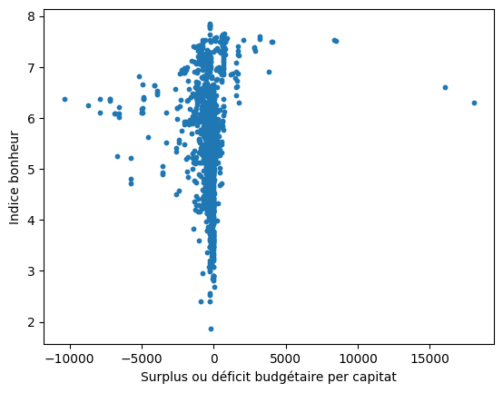

```python
plt.scatter((df_global.budget/100) * df_global.gdp, df_global["Happiness Score"], s=10)
plt.ylabel('Indice bonheur')
plt.xlabel('Surplus ou déficit budgétaire per capitat')
plt.show()
```

```python
df_temp = df_global[df_global.gdp.notnull() & df_global.budget.notnull()]
c_budget_gdp = stats.pearsonr((df_temp.budget/100) * df_temp.gdp, df_temp["Happiness Score"])
c_budget_gdp
```

```
PearsonRResult(statistic=-0.0069162454263637764, pvalue=0.8004585348821746)
```

```python
c_budget_gdp.statistic**2
```

```
4.783445079769785e-05
```

Le R<sup>2</sup> vraiment très bas indique qu'il n'y a pas de corrélation notable.

### Dépenses militaire (absolut per capita)

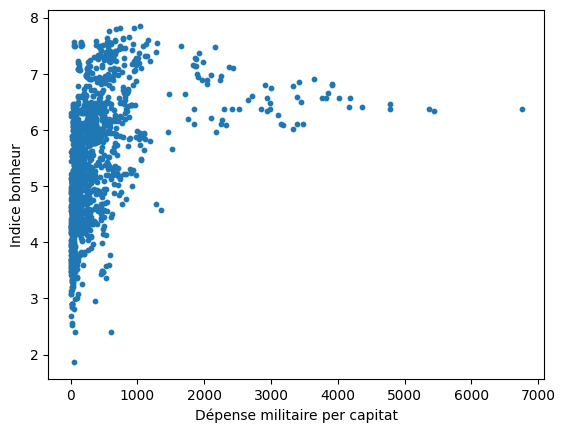

```python
plt.scatter((df_global.milit/100) * df_global.gdp, df_global["Happiness Score"], s=10)
plt.ylabel('Indice bonheur')
plt.xlabel('Dépense militaire per capitat')
plt.show()
```

Mais quelle est cette combinaison pays/année qui sort du lot autant du lot ?

```python
df_global.loc[(df_global.milit/100) * df_global.gdp == max((df_global.milit/100) * df_global.gdp)]
```

|  | annee | Country | Happiness Score | nativity | migration | health_expend | educ_expend | gdp | taxes | budget | milit |
| --- | --- | --- | --- | --- | --- | --- | --- | --- | --- | --- | --- |
| 191 | 2016 | Saudi Arabia | 6.379 | 18.4 | -0.5 | 4.7 | 5.1 | 53600.0 | 25.1 | -14.8 | 12.6 |

```python
df_temp = df_global[df_global.gdp.notnull() & df_global.milit.notnull()]
c_milit_gdp = stats.pearsonr((df_temp.milit/100) * df_temp.gdp, df_temp["Happiness Score"])
c_milit_gdp
```

```
PearsonRResult(statistic=0.38860690823505156, pvalue=1.789525976907318e-49)
```

```python
c_milit_gdp.statistic**2
```

```
0.15101532912800578
```

Le R<sup>2</sup> est de 0.1510 malgré la multiplication avec le PIB, ce qui est bas en comparaison avec les autres variables sur les dépenses budgétaires.